# An Analysis of Viking Runestones

Project 2

490357040, 490481703, 490411445, 490417311

University of Sydney | DATA1901 | Monday 12:00pm Lab 705-706 | September 2019

# 1 Initial Data Analysis

### Data Source

The two datasets used to produce this report (Master and Crosses) were derived from the [Scandinavian Runic-text Database] (http://www.nordiska.uu.se/forskn/samnord.htm) provided by Dr Alix Thoerming. It is not expected that the datasets provided are the most current versions available.

### Data Reliability and Limitations

Given that archaeological data are often compiled by multiple people with little to now contact, these datasets are restricted to the reliability of subjective judgement. In addition, they are limited by the numerous incomplete values. In an effort to obtain clean data for certain analyses, rows with missing values have been filtered out, reducing the number of runestones available for analysis. This is flagged when appropriate throughout the report.

### Variable Classification

The original Master dataset contains 4168 observations, representing a single rune, across 10 variables all classified as factors. Additional wrangling produced a Swedish only Master dataset, which is subsequently used for analysis throughout this report.

The Swedish Master data set contains 3220 observations, and covers only those runes found in Sweden. Several additional factor variables were created - provinces, earliestAD, latestAD - are the primary focus of this report.

The Crosses dataset contains 2397 runic observations across 54 variables: The signum variable (factor) is the primary key, Cross.Y.N (binary integer) indicates the presence of at least one cross, X. (integer) counts total crosses, and the remaining 51 variables (all integer) count the number of each particular type of cross.

### Stakeholders

Potential stakeholders include historians, archaeologists and educational institutions interested in conduction research on, or teaching about, the Viking Age.

```r
#Reads in master and crosses datasets

masterData = read.csv(file = "Arch_master_spreadsheet.csv", header = TRUE)
crossesData = read.csv(file = "Arch_crosses_spreadsheet.csv", header = TRUE)

#The remaining code in this block wrangles master dataset to create new variables to be used in analysis

##Create vectors for generalised style groups for earliest and latest dates.
##Note: KB by itself is classified as no date as it is not mentioned in the data dictionary.

###No Dates available, start and end
NoDateAvailable = c("", "?", "KB", "KB?")

###Start Dates
RAKStartDate = c("RAK", "RAK?", "RAK? [Gräslund muntligt]", "Fp (RAK)", "RAK??", "Fp - RAK?", "RAK - Pr1?", "RAK [Gräslund muntligt]")
FPStartDate = c("? (Fp)", "Fp?", "FP", "Fp, Pr1?", "Pr1 - Pr2?; Fp [Källström 2007a:361]", "Fp??", "Fp, Pr1 - Pr2", "Fp", "Fp, Pr2 - Pr3", "Fp, Pr2", "Fp [Gräslund muntligt]", "Fp, Pr1")
Pr1StartDate = c("Pr1", "Pr1? [Källström 2007a:362]", "Pr1 [En av, Ljung muntligt]", "Pr1 - Pr2", "Pr1 - Pr2? [Gräslund muntligt]", "Pr1 - Pr2?", "Pr1?", "Pr1 [Ljung muntligt]", "Pr1??")
Pr2StartDate = c("Pr2?", "sid a: Pr2, sid b: Pr2 - Pr3", "Pr2 [NOR 2004:27]", "Pr2 - Pr3?", "Pr2","Pr2 - Pr3", "KB? (Pr2 - Pr3)", "Pr2? [Klassificerad av redaktionen]", "Pr2 [Gräslund muntligt]", "Pr2 - Pr3 [Gräslund muntligt]", "Pr2 - Pr3? [Gräslund muntligt]", "KB, Pr2")
Pr3StartDate = c("Pr3 - Pr4?", "Pr3?", "Pr3 [Gräslund muntligt]", "Pr3 - Pr4 [Gräslund muntligt]", "Pr3? [Gräslund muntligt]", "Pr3??", "Pr3(?)", "Pr3", "Pr3 - Pr4", "Pr3 - Pr4??", "Pr3 [Fv 2009]", "Pr3 - Pr4? [Gräslund muntligt]")
Pr4StartDate = c("Pr4?", "Pr4 - Pr5", "Pr4", "Pr4? [Gräslund muntligt]", "Pr4 [Gräslund muntligt]", "Pr4 - Pr5?", "Pr4??", "Pr4 [Källström 2007a:407]")
Pr5StartDate = c("Pr5", "Pr5?", "Pr5? [Källström i SRI 10 Dig. suppl.]", "Pr5(?) [Fv 2012]")

###End dates
RAKEndDate = c("RAK", "RAK?", "RAK? [Gräslund muntligt]", "RAK??", "RAK [Gräslund muntligt]")
FPEndDate = c("? (Fp)", "Fp?", "FP", "Fp, Pr1?", "Pr1 - Pr2?; Fp [Källström 2007a:361]", "Fp??", "Fp, Pr1 - Pr2", "Fp", "Fp, Pr2", "Fp [Gräslund muntligt]", "Fp, Pr1", "Fp (RAK)", "Fp - RAK?")
Pr1EndDate = c("Pr1", "Pr1? [Källström 2007a:362]", "Pr1 [En av, Ljung muntligt]", "Pr1?", "Pr1 [Ljung muntligt]", "Pr1??", "RAK - Pr1?")
Pr2EndDate = c("Pr2?", "Pr2 [NOR 2004:27]", "Pr2", "Pr2? [Klassificerad av redaktionen]", "Pr2 [Gräslund muntligt]", "KB, Pr2", "Pr1 - Pr2", "Pr1 - Pr2? [Gräslund muntligt]", "Pr1 - Pr2?")
Pr3EndDate = c("Pr3?", "Pr3 [Gräslund muntligt]", "Pr3? [Gräslund muntligt]", "Pr3??", "Pr3(?)", "Pr3", "Pr3 [Fv 2009]", "Pr2 - Pr3", "Fp, Pr2 - Pr3", "KB? (Pr2 - Pr3)", "sid a: Pr2, sid b: Pr2 - Pr3", "Pr2 - Pr3?", "Pr2 - Pr3 [Gräslund muntligt]", "Pr2 - Pr3? [Gräslund muntligt]")
Pr4EndDate = c("Pr4?", "Pr4", "Pr4? [Gräslund muntligt]", "Pr4 [Gräslund muntligt]", "Pr4??", "Pr4 [Källström 2007a:407]", "Pr3 - Pr4? [Gräslund muntligt]", "Pr3 - Pr4?", "Pr3 - Pr4 [Gräslund muntligt]", "Pr3 - Pr4", "Pr3 - Pr4??")
Pr5EndDate = c("Pr4 - Pr5", "Pr4 - Pr5?", "Pr5", "Pr5?", "Pr5? [Källström i SRI 10 Dig. suppl.]", "Pr5(?) [Fv 2012]")

swedishProvinces = c("Bo", "D", "G", "Gs", "Hs", "J", "Lp", "M", "Nä", "Sm", "Sö", "U", "Vg", "Vr", "Vs", "Ög", "Öl")

##clean up the masterData dataset for analysis
masterDataClean = masterData %>%
              # add province column
              mutate(province = as.factor(str_trim(str_sub(masterData$Signum, 1, 2)))) %>%
              mutate(provinces = as.factor(case_when(province == "Bo" ~ "Bohuslän",
                                                    province == "D" ~ "Dalarna",
                                                    province == "G" ~ "Gotland",
                                                    province == "Gs" ~ "Gästrikland",
                                                    province == "Hs" ~ "Hälsingland",
                                                    province == "J" ~ "Jämtland",
                                                    province == "Lp" ~ "Lappland",
                                                    province == "M" ~ "Medelpad",
                                                    province == "Nä" ~ "Närke",
                                                    province == "Sm" ~ "Småland",
                                                    province == "Sö" ~ "Södermanland",
                                                    province == "U" ~ "Uppland",
                                                    province == "Vg" ~ "Västergötland",
                                                    province == "Vr" ~ "Värmland",
                                                    province == "Vs" ~ "Västmanland",
                                                    province == "Ög" ~ "Östergötland",
                                                    province == "Öl" ~ "Öland",
                                                    TRUE ~ as.character(province)
                                                    ))) %>%
              # rename columns to english names
              rename(place = Plats, parish = Socken, jurisdiction = Härad, municipality = Kommun,
                     coordinates = Koordinater, styleGroup = Stilgruppering, carver = Ristare,
                     material = Materialtyp, url = Bildlänk) %>%
              #filter province column to only runes found in Sweden as stated in data dictionary
              filter(province %in% swedishProvinces) %>%
              #drop unused levels once filtered out
              droplevels() %>%
              #add is column to indicate if individual signum is is the crosses dataset
              mutate(inCrosses = (Signum %in% crossesData$Signum)) %>%
              # create new column identifying earliest approximate start date based on style group
              mutate(earliestAD = as.factor(case_when(styleGroup %in% RAKStartDate ~ "990",
                                                      styleGroup %in% FPStartDate ~ "1010",
                                                      styleGroup %in% Pr1StartDate ~ "1010",
                                                      styleGroup %in% Pr2StartDate ~ "1020",
                                                      styleGroup %in% Pr3StartDate ~ "1050",
                                                      styleGroup %in% Pr4StartDate ~ "1060",
                                                      styleGroup %in% Pr5StartDate ~ "1100",
                                                      styleGroup %in% NoDateAvailable ~ NA_character_,
                                                      TRUE ~ as.character(styleGroup)))) %>%
              # create new column identifying latest approximate end date based on style group
              mutate(latestAD = as.factor(case_when(styleGroup %in% RAKEndDate ~ "1010",
                                                    styleGroup %in% FPEndDate ~ "1050",
                                                    styleGroup %in% Pr1EndDate ~ "1040",
                                                    styleGroup %in% Pr2EndDate ~ "1050",
                                                    styleGroup %in% Pr3EndDate ~ "1070",
                                                    styleGroup %in% Pr4EndDate ~ "1100",
                                                    styleGroup %in% Pr5EndDate ~ "1130",
                                                    styleGroup %in% NoDateAvailable ~ NA_character_,
                                                    TRUE ~ as.character(styleGroup)))) %>%
              #adds logic vector indicating if rune has a date allocated
              mutate(hasDate = (earliestAD %in% c("990", "1010", "1020", "1050", "1060", "1100")))

masterDataCleanNoNA = masterDataClean %>% filter(earliestAD != "NA" & latestAD != "NA")

merged = merge(masterDataCleanNoNA, crossesData, by = "Signum")

TimeNumCrossData <- merged %>%
  select(latestAD, 19)%>%
  filter(latestAD != "?" & latestAD != "")


write.csv(TimeNumCrossData, "TimeNumCrossData.csv") ### this file gets passed to the python program

#IDA
head(masterData)
```

```
##     Signum                Plats        Socken         Härad     Kommun
## 1  Öl 1 $               Karlevi   Vickleby sn Algutsrums hd Mörbylånga
## 2 Öl 2 †$      Algutsrums kyrka Algutsrums sn Algutsrums hd Mörbylånga
## 3 Öl 3 †$           Resmo kyrka      Resmo sn Algutsrums hd Mörbylånga
## 4  Öl 4 $           Resmo kyrka      Resmo sn Algutsrums hd Mörbylånga
## 5  Öl 5 †                 Bårby Mörbylånga sn Algutsrums hd Mörbylånga
## 6  Öl 6 $  Mörbylånga kyrkogård Mörbylånga sn Algutsrums hd Mörbylånga
##       Koordinater Stilgruppering Ristare Materialtyp
## 1 6275755.1538971            RAK                sten
## 2 6283750.1544290            Pr3                sten
## 3 6268390.1539280     Pr3 - Pr4?                sten
## 4 6268390.1539280            Pr4                sten
## 5 6264000.1538250            Pr3                sten
## 6 6265940.1536510            Pr4                sten
##                                                                         Bildlänk
## 1 http://kmb.raa.se/cocoon/bild/object_list_simple?query=Öl1&showthumbnails=true
## 2
## 3
## 4
## 5
## 6
```

```r
head(crossesData)
```

```
##              Signum Cross.Y.N X. A1 A2 A3 A4 A5 A6 A7 A8 A9 B1 B2 B3 B4 C1
## 1      Bo Boije4 $          0  0  0  0  0  0  0  0  0  0  0  0  0  0  0  0
## 2       Bo Boije5           0  0  0  0  0  0  0  0  0  0  0  0  0  0  0  0
## 3        Bo KJ80 $          0  0  0  0  0  0  0  0  0  0  0  0  0  0  0  0
## 4      Bo NIYR;4 $          0  0  0  0  0  0  0  0  0  0  0  0  0  0  0  0
## 5 Bo Peterson1992           0  0  0  0  0  0  0  0  0  0  0  0  0  0  0  0
## 6  D Fv1993;174             0  0  0  0  0  0  0  0  0  0  0  0  0  0  0  0
##   C10 C11 C2 C3 C4 C5 C6 C7 C8 C9 D1 D2 D3 D4 D5 D6 E1 E10 E11 E2 E3 E4 E5
## 1   0   0  0  0  0  0  0  0  0  0  0  0  0  0  0  0  0   0   0  0  0  0  0
## 2   0   0  0  0  0  0  0  0  0  0  0  0  0  0  0  0  0   0   0  0  0  0  0
## 3   0   0  0  0  0  0  0  0  0  0  0  0  0  0  0  0  0   0   0  0  0  0  0
## 4   0   0  0  0  0  0  0  0  0  0  0  0  0  0  0  0  0   0   0  0  0  0  0
## 5   0   0  0  0  0  0  0  0  0  0  0  0  0  0  0  0  0   0   0  0  0  0  0
## 6   0   0  0  0  0  0  0  0  0  0  0  0  0  0  0  0  0   0   0  0  0  0  0
##   E6 E7 E8 E9 F1 F2 F3 F4 G1 G2 G3 G4 G5 G6
## 1  0  0  0  0  0  0  0  0  0  0  0  0  0  0
## 2  0  0  0  0  0  0  0  0  0  0  0  0  0  0
## 3  0  0  0  0  0  0  0  0  0  0  0  0  0  0
## 4  0  0  0  0  0  0  0  0  0  0  0  0  0  0
## 5  0  0  0  0  0  0  0  0  0  0  0  0  0  0
## 6  0  0  0  0  0  0  0  0  0  0  0  0  0  0
```

```r
head(masterDataClean)
```

```
##     Signum                place        parish  jurisdiction municipality
## 1  Öl 1 $               Karlevi   Vickleby sn Algutsrums hd   Mörbylånga
## 2 Öl 2 †$      Algutsrums kyrka Algutsrums sn Algutsrums hd   Mörbylånga
## 3 Öl 3 †$           Resmo kyrka      Resmo sn Algutsrums hd   Mörbylånga
## 4  Öl 4 $           Resmo kyrka      Resmo sn Algutsrums hd   Mörbylånga
## 5  Öl 5 †                 Bårby Mörbylånga sn Algutsrums hd   Mörbylånga
## 6  Öl 6 $  Mörbylånga kyrkogård Mörbylånga sn Algutsrums hd   Mörbylånga
##       coordinates styleGroup carver material
## 1 6275755.1538971        RAK            sten
## 2 6283750.1544290        Pr3            sten
## 3 6268390.1539280 Pr3 - Pr4?            sten
## 4 6268390.1539280        Pr4            sten
## 5 6264000.1538250        Pr3            sten
## 6 6265940.1536510        Pr4            sten
##                                                                              url
## 1 http://kmb.raa.se/cocoon/bild/object_list_simple?query=Öl1&showthumbnails=true
## 2
## 3
## 4
## 5
## 6
##   province provinces inCrosses earliestAD latestAD hasDate
## 1       Öl     Öland      TRUE        990     1010    TRUE
## 2       Öl     Öland     FALSE       1050     1070    TRUE
## 3       Öl     Öland     FALSE       1050     1100    TRUE
## 4       Öl     Öland      TRUE       1060     1100    TRUE
## 5       Öl     Öland     FALSE       1050     1070    TRUE
## 6       Öl     Öland      TRUE       1060     1100    TRUE
```

```r
dim(masterData)
```

```
## [1] 4168   10
```

```r
dim(crossesData)
```

```
## [1] 2397   54
```

```r
dim(masterDataClean)
```

```
## [1] 3220   16
```

```r
class(masterData)
```

```
## [1] "data.frame"
```

```r
class(crossesData)
```

```
## [1] "data.frame"
```

```r
class(masterDataClean)
```

```
## [1] "data.frame"
```

```r
str(masterData)
```

```
## 'data.frame':    4168 obs. of  10 variables:
##  $ Signum        : Factor w/ 4168 levels "Ån Fv1908;298A $ ",..: 1711 1722 1733 1743 1754 1764 1765 1766 1767 1712 ...
##  $ Plats         : Factor w/ 2440 levels "?","\"Flasta mur\", kyrkoruin",..: 1000 43 1623 1623 180 1334 1333 1334 1009 75 ...
##  $ Socken        : Factor w/ 1180 levels "","?","Å sn",..: 1147 15 766 766 624 624 624 624 501 884 ...
##  $ Härad         : Factor w/ 377 levels "","?","?, Sverige",..: 10 10 10 10 10 10 10 10 103 103 ...
##  $ Kommun        : Factor w/ 347 levels "","?","Aabenraa",..: 175 175 175 175 175 175 175 175 175 175 ...
##  $ Koordinater   : Factor w/ 2926 levels "","?TR 155579 (51.2789086111111 ; 1.0903125)",..: 347 359 336 336 330 332 332 332 326 321 ...
##  $ Stilgruppering: Factor w/ 69 levels "","?","? (Fp)",..: 63 39 42 51 39 51 39 1 33 33 ...
##  $ Ristare       : Factor w/ 509 levels "","-älv (S)",..: 1 1 1 1 1 1 1 1 1 1 ...
##  $ Materialtyp   : Factor w/ 1 level "sten": 1 1 1 1 1 1 1 1 1 1 ...
##  $ Bildlänk      : Factor w/ 724 levels "","http://carlotta.gotlib.goteborg.se/zoom/172/GM_367_detalj1.jpg",..: 65 1 1 1 1 1 1 1 1 1 ...
```

```r
str(crossesData)
```

```
## 'data.frame':    2397 obs. of  54 variables:
##  $ Signum   : Factor w/ 2397 levels "Bo Boije4 $ ",..: 1 2 3 4 5 6 7 8 9 10 ...
##  $ Cross.Y.N: int  0 0 0 0 0 0 0 0 0 0 ...
##  $ X.       : int  0 0 0 0 0 0 0 0 0 0 ...
##  $ A1       : int  0 0 0 0 0 0 0 0 0 0 ...
##  $ A2       : int  0 0 0 0 0 0 0 0 0 0 ...
##  $ A3       : int  0 0 0 0 0 0 0 0 0 0 ...
##  $ A4       : int  0 0 0 0 0 0 0 0 0 0 ...
##  $ A5       : int  0 0 0 0 0 0 0 0 0 0 ...
##  $ A6       : int  0 0 0 0 0 0 0 0 0 0 ...
##  $ A7       : int  0 0 0 0 0 0 0 0 0 0 ...
##  $ A8       : int  0 0 0 0 0 0 0 0 0 0 ...
##  $ A9       : int  0 0 0 0 0 0 0 0 0 0 ...
##  $ B1       : int  0 0 0 0 0 0 0 0 0 0 ...
##  $ B2       : int  0 0 0 0 0 0 0 0 0 0 ...
```

[output cut: 40 more lines]

```r
str(masterDataClean)
```

```
## 'data.frame':    3220 obs. of  16 variables:
##  $ Signum      : Factor w/ 3220 levels "Bo Boije4 $ ",..: 838 849 860 870 881 891 892 893 894 839 ...
##  $ place       : Factor w/ 1725 levels "?","\"Flasta mur\", kyrkoruin",..: 676 35 1114 1114 125 917 916 917 683 56 ...
##  $ parish      : Factor w/ 741 levels "?","Å sn","Åby sn",..: 716 9 468 468 384 384 384 384 307 546 ...
##  $ jurisdiction: Factor w/ 182 levels "","?","Åkerbo hd",..: 7 7 7 7 7 7 7 7 53 53 ...
##  $ municipality: Factor w/ 140 levels "?","Alingsås",..: 69 69 69 69 69 69 69 69 69 69 ...
##  $ coordinates : Factor w/ 2561 levels "","6241046.1542160",..: 37 49 26 26 20 22 22 22 16 11 ...
##  $ styleGroup  : Factor w/ 69 levels "","?","? (Fp)",..: 63 39 42 51 39 51 39 1 33 33 ...
##  $ carver      : Factor w/ 447 levels "","-älv (S)",..: 1 1 1 1 1 1 1 1 1 1 ...
##  $ material    : Factor w/ 1 level "sten": 1 1 1 1 1 1 1 1 1 1 ...
##  $ url         : Factor w/ 674 levels "","http://carlotta.gotlib.goteborg.se/zoom/172/GM_367_detalj1.jpg",..: 65 1 1 1 1 1 1 1 1 1 ...
##  $ province    : Factor w/ 17 levels "Bo","D","G","Gs",..: 11 11 11 11 11 11 11 11 11 11 ...
##  $ provinces   : Factor w/ 17 levels "Bohuslän","Dalarna",..: 10 10 10 10 10 10 10 10 10 10 ...
##  $ inCrosses   : logi  TRUE FALSE FALSE TRUE FALSE TRUE ...
##  $ earliestAD  : Factor w/ 6 levels "1010","1020",..: 6 3 3 4 3 4 3 NA 2 2 ...
##  $ latestAD    : Factor w/ 6 levels "1010","1040",..: 1 4 5 5 4 5 4 NA 4 4 ...
##  $ hasDate     : logi  TRUE TRUE TRUE TRUE TRUE TRUE ...
```

```r
# Classification of variables of from original master dataset and clean master dataset
sapply(masterData, class)
```

```
##         Signum          Plats         Socken          Härad         Kommun
##       "factor"       "factor"       "factor"       "factor"       "factor"
##    Koordinater Stilgruppering        Ristare    Materialtyp       Bildlänk
##       "factor"       "factor"       "factor"       "factor"       "factor"
```

```r
sapply(masterDataClean, class)
```

```
##       Signum        place       parish jurisdiction municipality
##     "factor"     "factor"     "factor"     "factor"     "factor"
##  coordinates   styleGroup       carver     material          url
##     "factor"     "factor"     "factor"     "factor"     "factor"
##     province    provinces    inCrosses   earliestAD     latestAD
##     "factor"     "factor"    "logical"     "factor"     "factor"
##      hasDate
##    "logical"
```

```r
#Readjust levels for graphs
levels(masterDataCleanNoNA$earliestAD) = c("990", "1010", "1020", "1050", "1060", "1100")
levels(masterDataCleanNoNA$latestAD) = c("1010", "1040", "1050", "1070",  "1100", "1130")
```

# 2 Research Question

> Are there any noticeable trends in how runestones and typological cross features are distributed throughout time and place?

### Location

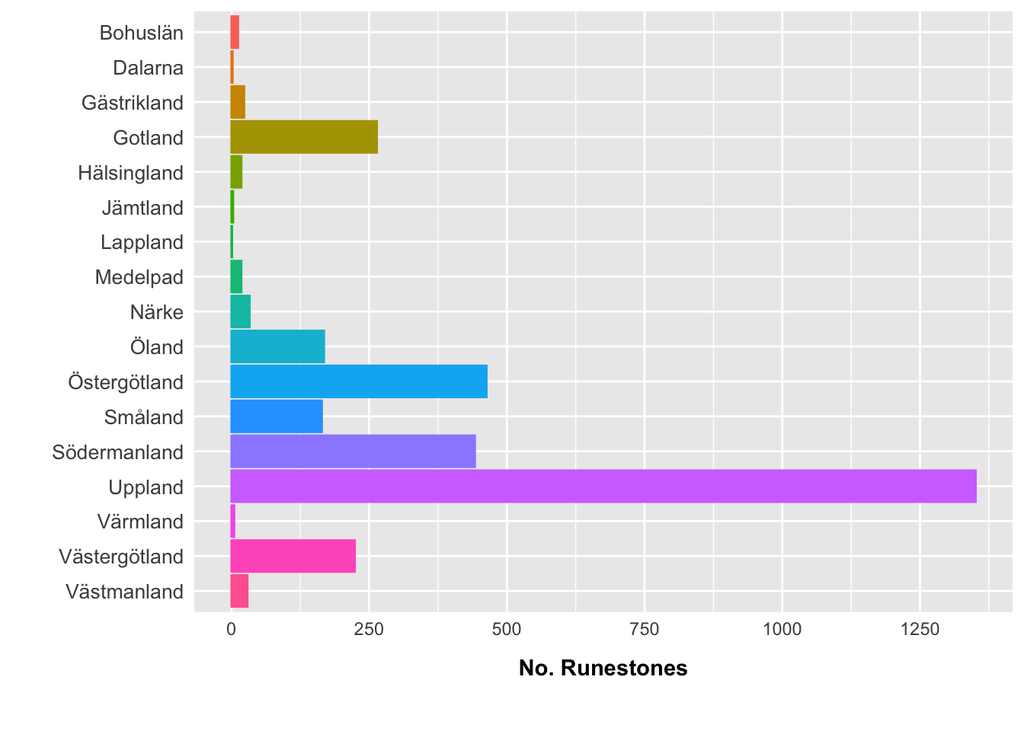

<sup>**Figure 1. Count of runestones found in each viking-era Swedish province**</sup>

```r
#counts the total number of runes in each province
runesInProvince = ggplot(masterDataClean, aes(x = reorder(provinces, desc(provinces)) , colour = masterDataClean$provinces, fill = masterDataClean$provinces))
runesInProvince +
  geom_bar() +
  coord_flip() +
  theme(axis.title.y = element_text(margin = margin(t = 0, r = 10, b = 0, l = 0)), axis.text.y = element_text(size = 10)) +
  theme(axis.title.x = element_text(margin = margin(t = 10, r = 0, b = 20, l = 0), face = "bold"), axis.ticks = element_blank()) +
  xlab(paste("")) +
  ylab("No. Runestones") +
  theme(legend.position = "none") +
  scale_y_continuous(breaks=c(0, 250, 500, 750, 1000, 1250))
```

```r
#Focuses on those provinces with less than 100 runes found
#runesInProvince + geom_bar() + coord_flip(ylim = c(0,50))
```

```r
countOfProvTable = table(masterDataClean$provinces)
countOfProvTable
```

```
##
##      Bohuslän       Dalarna   Gästrikland       Gotland   Hälsingland
##            12             2            23           264            18
##      Jämtland      Lappland      Medelpad         Närke         Öland
##             3             1            18            33           168
##  Östergötland       Småland  Södermanland       Uppland      Värmland
##           463           164           442          1351             5
## Västergötland   Västmanland
##           224            29
```

```r
propOfProvTable = prop.table(table(masterDataClean$provinces))
propOfProvTable
```

```
##
##      Bohuslän       Dalarna   Gästrikland       Gotland   Hälsingland
##   0.003726708   0.000621118   0.007142857   0.081987578   0.005590062
##      Jämtland      Lappland      Medelpad         Närke         Öland
##   0.000931677   0.000310559   0.005590062   0.010248447   0.052173913
##  Östergötland       Småland  Södermanland       Uppland      Värmland
##   0.143788820   0.050931677   0.137267081   0.419565217   0.001552795
## Västergötland   Västmanland
##   0.069565217   0.009006211
```

### Dates

The precise dating of runestones has proven to be highly difficult through conventional methods. As large stones carry insufficient amounts of organic material required for carbon dating, various statistical and stylistic classification systems have instead been developed (Lewis, 2005; Thoeming, 2016). This data uses the classificatory system developed by Lager in 2002, where each stone is allocated into 51 sub-classes of 7 main groups, attempting to date the runestones by the carving design. Just over half of the Swedish runestones have been dated using the stylistic method (Figure 2).

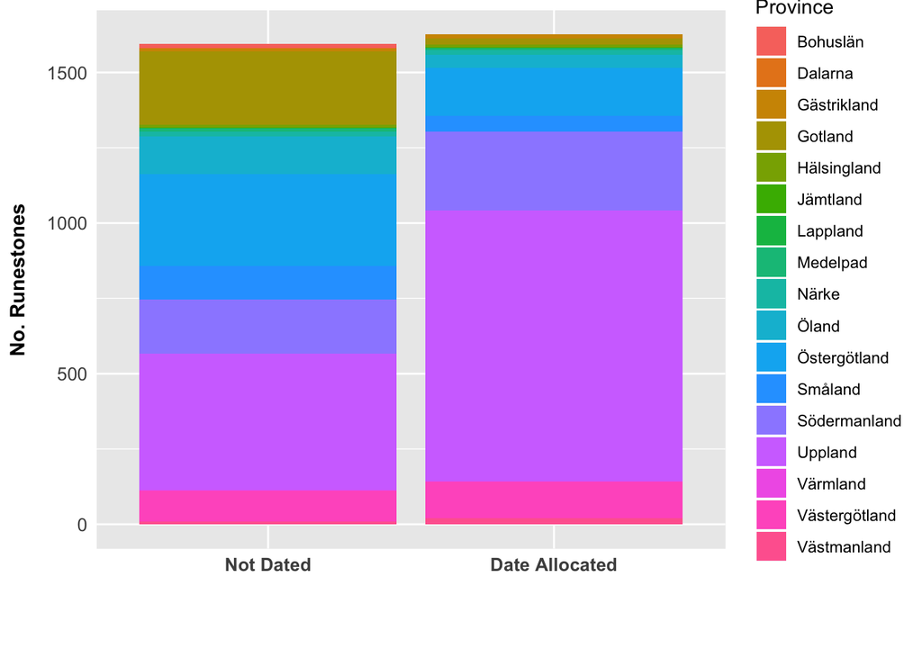

<sup>**Figure 2. Number of runestones that have been dated using Lager’s stylistic method compared to those that have not date.**</sup>

```r
#Compares how many runes have dates by provinces
runesInEarliestDateByProv = ggplot(masterDataClean, aes(x = (earliestAD %in% c("990", "1010", "1020", "1050", "1060", "1100")), fill = masterDataClean$provinces))
runesInEarliestDateByProv +
  geom_bar() +
  theme(axis.title.y = element_text(margin = margin(t = 0, r = 10, b = 0, l = 0), face = "bold"), axis.text.y = element_text(size = 10)) +
  theme(axis.title.x = element_text(margin = margin(t = 10, r = 0, b = 20, l = 0), face = "bold"), axis.ticks = element_blank(), axis.text.x = element_text(face = "bold", size = 10)) +
  xlab(paste("")) +
  ylab("No. Runestones") +
  labs(fill = "Province") +
  scale_x_discrete(labels = c("Not Dated", "Date Allocated"))
```

However, it is clearly not evenly distributed across the provinces. When we look at the proportion of dated to not dated runes on a province-by-province scale we see that a that only 5 of the 17 provinces have more than half of their runes dated (Figure 3). Similar to Simpson’s Paradox, when viewed from this perspective one might assume that current dating methods are not particularly comprehensive. While this view may not necessarily be right, this figure does still raise concerns for the ability of the current method to suggest dates for runes found in less represented provinces.

```r
#Creates table of proportion of runes that have been dated
hasDatePropTable = prop.table(table(masterDataClean$provinces, masterDataClean$hasDate), 1)
hasDatePropDF = as.data.frame(hasDatePropTable)
prop.table(table(masterDataClean$hasDate))
```

```
##
##     FALSE      TRUE
## 0.4950311 0.5049689
```

[figure not shown]

<sup>**Figure 3. Proportion of runes found in each province that have been allocated a date.**</sup>

```r
hasDatePropBarPlot = ggplot(hasDatePropDF, aes(x = Var1, y = Freq, fill = Var2))
hasDatePropBarPlot +
  geom_bar(stat="identity") +
  coord_flip() +
  theme(axis.title.y = element_text(margin = margin(t = 0, r = 10, b = 0, l = 0)), axis.text.y = element_text(size = 10)) +
  theme(axis.title.x = element_text(margin = margin(t = 10, r = 0, b = 20, l = 0), face = "bold"), axis.ticks = element_blank()) +
  xlab(paste("")) +
  ylab("No. Runestones") +
  scale_fill_discrete(name = "Allocated Date", labels = c("Yes", "No"))
```

```r
  #labs(fill = "Allocated Date")
```

For all runestones that have been dated by Lager’s technique (50.5%), an earliest and latest possible date has been allocated loosely based on its designated style group. If the style group references two periods, then the earliest start date takes the starting year of the earliest period mentioned, and the latest end date takes the ending year of the latest period mentioned.

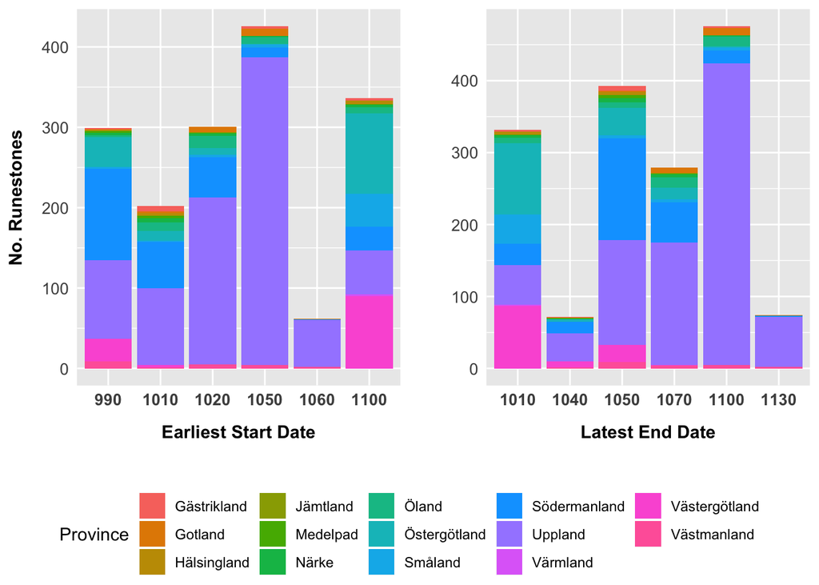

```r
#counts the total number of runes in each province

runesInEarliestDateByProv = ggplot(masterDataCleanNoNA, aes(x = earliestAD, fill = provinces))
plot1 = runesInEarliestDateByProv + geom_bar() + theme(axis.title.y = element_text(margin = margin(t = 0, r = 10, b = 0, l = 0), face = "bold"), axis.text.y = element_text(size = 10)) + theme(axis.title.x = element_text(margin = margin(t = 10, r = 0, b = 20, l = 0), face = "bold"), axis.ticks = element_blank(), axis.text.x = element_text(face = "bold", size = 10)) + xlab(paste("Earliest Start Date")) +ylab("No. Runestones") + labs(fill = "Province")



runesInLatestDateByProv = ggplot(masterDataCleanNoNA, aes(x = latestAD, fill = provinces))
plot2 = runesInLatestDateByProv + geom_bar() + theme(axis.title.y = element_text(margin = margin(t = 0, r = 10, b = 0, l = 0), face = "bold"), axis.text.y = element_text(size = 10)) + theme(axis.title.x = element_text(margin = margin(t = 10, r = 0, b = 20, l = 0), face = "bold"), axis.ticks = element_blank(), axis.text.x = element_text(face = "bold", size = 10)) + xlab(paste("Latest End Date")) +ylab("") + labs(fill = "Province")

ggarrange(plot1, plot2, ncol=2, common.legend = TRUE, legend="bottom")
```

Given that features are known to corroborate with historical dates such as inscriptions of a certain king, the peaks and troughs observed in Figure 4 could be matched to the time period of changing political circumstances.

However the lack of similarity in trends observed across provinces (Figure 5) indicates that despite the high mobility and sociability of the Vikings, nuanced socio-political may be more influential within any given province.

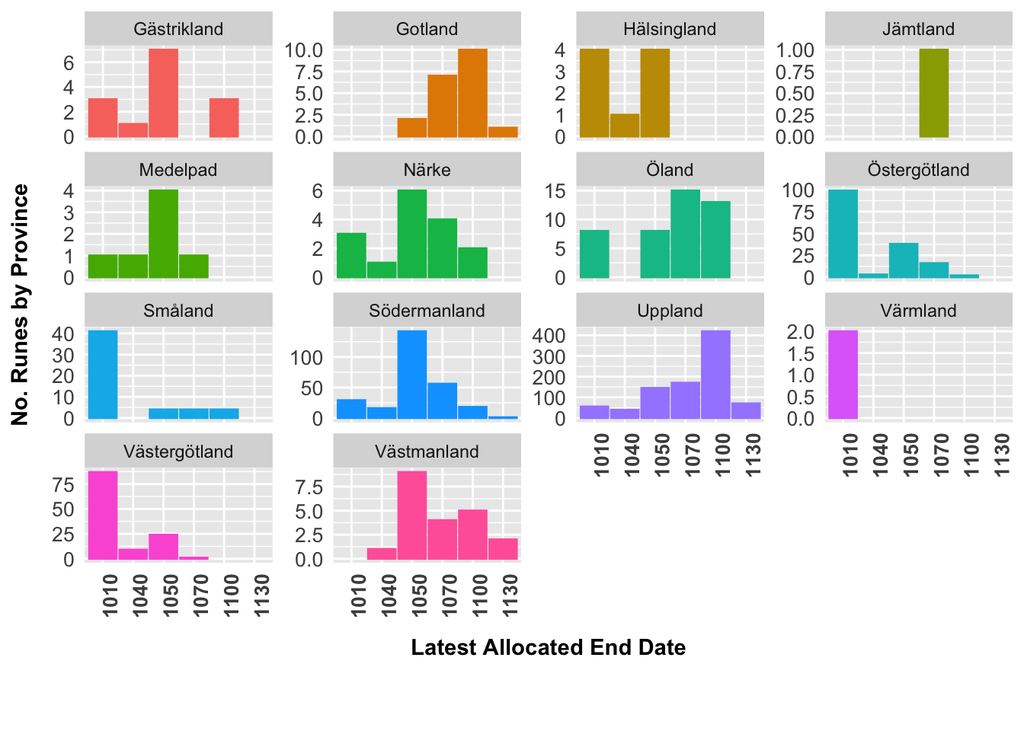

<sup>**Figure 5. Number of runestones found across time periods (using the Latest end date), faceted by province.**</sup>

```r
#distirbution of rune across time period, faceted by province
runesInLatestDateFacetProv = ggplot(masterDataCleanNoNA, aes(x = latestAD, colour = masterDataCleanNoNA$provinces, fill = masterDataCleanNoNA$provinces))
runesInLatestDateFacetProv +
      geom_bar() +
      facet_wrap(masterDataCleanNoNA$provinces, scales = "free_y") +
      theme(axis.text.x=element_text(angle=90)) +
      theme(axis.title.y = element_text(margin = margin(t = 0, r = 10, b = 0, l = 0), face = "bold"), axis.text.y = element_text(size = 10)) +
      theme(axis.title.x = element_text(margin = margin(t = 10, r = 0, b = 30, l = 0), face = "bold"), axis.ticks = element_blank(), axis.text.x = element_text(face = "bold", size = 10)) +
      xlab(paste("Latest Allocated End Date")) +
      ylab("No. Runes by Province") +
      theme(legend.position = "none")
```

### Crosses

Runes were designed to pay tribute to the life of a highly regarded individual, and were strategically located to mark territories. They were marked with runic text, decoration featuring stylised ‘rune animals’ and in some cases Christian crosses.

```r
#makes vector of all distinct Signums across both master and crosses datasets
#makes two logic vectors based on whether signum is found master and crosses dataset
#makes contingency table of where all signums can be found
#Note that the crosses dataset already only contained Swedish signums, whereas the master dataset was filtered previously

masterSignum = as.vector(masterDataClean$Signum)
crossesSignum = as.vector(crossesData$Signum)
allSignums = as.vector(unique(c(masterSignum, crossesSignum)))
str(allSignums)
```

```
##  chr [1:3763] "Öl 1 $ " "Öl 2 †$ " "Öl 3 †$ " "Öl 4 $ " "Öl 5 † " ...
```

```r
masterFromTotal = allSignums %in% masterSignum
str(masterFromTotal)
```

```
##  logi [1:3763] TRUE TRUE TRUE TRUE TRUE TRUE ...
```

```r
crossesFromTotal = allSignums %in% crossesSignum

crossesMasterContTable = table(crossesFromTotal, masterFromTotal)
crossesMasterContTable
```

```
##                 masterFromTotal
## crossesFromTotal FALSE TRUE
##            FALSE     0 1366
##            TRUE    543 1854
```

| Table 1. Allocation of runes within datasets | Not in Master | In Master |
| --- | --- | --- |
| **Not in Crosses** | 0 | 1366 |
| **In Crosses** | 543 | 1854 |

Of those runestones found in both datasets (n = 1854), only 715 runes had both an approximated date range (from the Master dataset) and at least one cross as a feature (from the Crosses dataset) (Table 2).

```r
merged <- merge(masterData, crossesData, by="Signum")
str(merged)
```

```
## 'data.frame':    1854 obs. of  63 variables:
##  $ Signum        : Factor w/ 4168 levels "Ån Fv1908;298A $ ",..: 3 4 7 14 19 426 428 429 430 431 ...
##  $ Plats         : Factor w/ 2440 levels "?","\"Flasta mur\", kyrkoruin",..: 1831 2254 1615 826 1403 1472 2125 109 109 109 ...
##  $ Socken        : Factor w/ 1180 levels "","?","Å sn",..: 861 1021 1063 929 953 26 26 43 43 43 ...
##  $ Härad         : Factor w/ 377 levels "","?","?, Sverige",..: 362 301 319 237 74 89 89 168 168 168 ...
##  $ Kommun        : Factor w/ 347 levels "","?","Aabenraa",..: 277 265 297 203 30 80 80 80 80 80 ...
##  $ Koordinater   : Factor w/ 2926 levels "","?TR 155579 (51.2789086111111 ; 1.0903125)",..: 1320 1093 781 793 2816 528 533 555 555 555 ...
##  $ Stilgruppering: Factor w/ 69 levels "","?","? (Fp)",..: 1 1 1 1 1 2 2 31 2 47 ...
##  $ Ristare       : Factor w/ 509 levels "","-älv (S)",..: 1 1 1 1 1 1 1 1 1 209 ...
##  $ Materialtyp   : Factor w/ 1 level "sten": 1 1 1 1 1 1 1 1 1 1 ...
##  $ Bildlänk      : Factor w/ 724 levels "","http://carlotta.gotlib.goteborg.se/zoom/172/GM_367_detalj1.jpg",..: 192 1 86 3 1 1 330 202 199 331 ...
##  $ Cross.Y.N     : int  0 0 0 0 0 0 0 0 0 0 ...
##  $ X.            : int  0 0 0 0 0 0 0 0 0 0 ...
##  $ A1            : int  0 0 0 0 0 0 0 0 0 0 ...
##  $ A2            : int  0 0 0 0 0 0 0 0 0 0 ...
```

[output cut: 49 more lines]

```r
countsDateCross = merged %>%
  select(Signum, Stilgruppering, Cross.Y.N) %>%
  rename(Date = Stilgruppering) %>%
  #rename(Cross.Y.N = 'Cross Y/N') %>%
  mutate(hasDate = (Date != "?" & !is.na(Date))) %>%
  mutate(hasCross= (Cross.Y.N == 1))

hasDate <- countsDateCross$hasDate
hasCross <- countsDateCross$hasCross

t <- table(hasDate, hasCross)
t
```

```
##        hasCross
## hasDate FALSE TRUE
##   FALSE   252  104
##   TRUE    783  715
```

[output not shown]

```r
library(readxl)
library(dplyr)
library(tidyverse)
library(geosphere)
library(ggplot2)
library(plotly)
library(RgoogleMaps)
library(ggmap)

masterData = read_excel("Arch_master_spreadsheet.xls")
crossesData = read_excel("Arch_crosses_spreadsheet.xlsx")

#Create vectors for generalised style groups for earliest and latest dates.
#Note: KB by itself is classified as no date as it is not mentioned in the data dictionary.

####No Dates available, start and end
NoDateAvailable = c("", "?", "KB", "KB?")

#### Start Dates
RAKStartDate = c("RAK", "RAK?", "RAK? [Gräslund muntligt]", "Fp (RAK)", "RAK??", "Fp - RAK?", "RAK - Pr1?", "RAK [Gräslund muntligt]")
FPStartDate = c("? (Fp)", "Fp?", "FP", "Fp, Pr1?", "Pr1 - Pr2?; Fp [Källström 2007a:361]", "Fp??", "Fp, Pr1 - Pr2", "Fp", "Fp, Pr2 - Pr3", "Fp, Pr2", "Fp [Gräslund muntligt]", "Fp, Pr1")
Pr1StartDate = c("Pr1", "Pr1? [Källström 2007a:362]", "Pr1 [En av, Ljung muntligt]", "Pr1 - Pr2", "Pr1 - Pr2? [Gräslund muntligt]", "Pr1 - Pr2?", "Pr1?", "Pr1 [Ljung muntligt]", "Pr1??")
Pr2StartDate = c("Pr2?", "sid a: Pr2, sid b: Pr2 - Pr3", "Pr2 [NOR 2004:27]", "Pr2 - Pr3?", "Pr2","Pr2 - Pr3", "KB? (Pr2 - Pr3)", "Pr2? [Klassificerad av redaktionen]", "Pr2 [Gräslund muntligt]", "Pr2 - Pr3 [Gräslund muntligt]", "Pr2 - Pr3? [Gräslund muntligt]", "KB, Pr2")
Pr3StartDate = c("Pr3 - Pr4?", "Pr3?", "Pr3 [Gräslund muntligt]", "Pr3 - Pr4 [Gräslund muntligt]", "Pr3? [Gräslund muntligt]", "Pr3??", "Pr3(?)", "Pr3", "Pr3 - Pr4", "Pr3 - Pr4??", "Pr3 [Fv 2009]", "Pr3 - Pr4? [Gräslund muntligt]")
Pr4StartDate = c("Pr4?", "Pr4 - Pr5", "Pr4", "Pr4? [Gräslund muntligt]", "Pr4 [Gräslund muntligt]", "Pr4 - Pr5?", "Pr4??", "Pr4 [Källström 2007a:407]")
Pr5StartDate = c("Pr5", "Pr5?", "Pr5? [Källström i SRI 10 Dig. suppl.]", "Pr5(?) [Fv 2012]")

#####End dates
RAKEndDate = c("RAK", "RAK?", "RAK? [Gräslund muntligt]", "RAK??", "RAK [Gräslund muntligt]")
FPEndDate = c("? (Fp)", "Fp?", "FP", "Fp, Pr1?", "Pr1 - Pr2?; Fp [Källström 2007a:361]", "Fp??", "Fp, Pr1 - Pr2", "Fp", "Fp, Pr2", "Fp [Gräslund muntligt]", "Fp, Pr1", "Fp (RAK)", "Fp - RAK?")
Pr1EndDate = c("Pr1", "Pr1? [Källström 2007a:362]", "Pr1 [En av, Ljung muntligt]", "Pr1?", "Pr1 [Ljung muntligt]", "Pr1??", "RAK - Pr1?")
Pr2EndDate = c("Pr2?", "Pr2 [NOR 2004:27]", "Pr2", "Pr2? [Klassificerad av redaktionen]", "Pr2 [Gräslund muntligt]", "KB, Pr2", "Pr1 - Pr2", "Pr1 - Pr2? [Gräslund muntligt]", "Pr1 - Pr2?")
Pr3EndDate = c("Pr3?", "Pr3 [Gräslund muntligt]", "Pr3? [Gräslund muntligt]", "Pr3??", "Pr3(?)", "Pr3", "Pr3 [Fv 2009]", "Pr2 - Pr3", "Fp, Pr2 - Pr3", "KB? (Pr2 - Pr3)", "sid a: Pr2, sid b: Pr2 - Pr3", "Pr2 - Pr3?", "Pr2 - Pr3 [Gräslund muntligt]", "Pr2 - Pr3? [Gräslund muntligt]")
Pr4EndDate = c("Pr4?", "Pr4", "Pr4? [Gräslund muntligt]", "Pr4 [Gräslund muntligt]", "Pr4??", "Pr4 [Källström 2007a:407]", "Pr3 - Pr4? [Gräslund muntligt]", "Pr3 - Pr4?", "Pr3 - Pr4 [Gräslund muntligt]", "Pr3 - Pr4", "Pr3 - Pr4??")
Pr5EndDate = c("Pr4 - Pr5", "Pr4 - Pr5?", "Pr5", "Pr5?", "Pr5? [Källström i SRI 10 Dig. suppl.]", "Pr5(?) [Fv 2012]")


#clean up the masterData dataset for analysis
masterData1 = masterData %>%
              # add in generic ID column and province column
              mutate(ID = row_number(), province = as.factor(str_trim(str_sub(masterData$Signum, 1, 2)))) %>%
              # rename columns to english names
              rename(place = Plats, parish = Socken, jurisdiction = Härad, municipality = Kommun,
                     coordinates = Koordinater, styleGroup = Stilgruppering, carver = Ristare,
                     material = Materialtyp, url = Bildlänk) %>%
              #filter province column to only runes found in Sweden as stated in data dictionary
              filter(province %in% c("Bo", "D", "G", "Gs", "Hs", "J", "Lp", "M", "Nä", "Sm", "Sö",
                                     "U", "Vg", "Vr", "Vs", "Ög", "Öl")) %>%
              #drop unused levels once filtered out
              droplevels() %>%
              #add is column to indicate if individual signum is is the crosses dataset
              mutate(inCrosses = (Signum %in% crossesData$Signum)) %>%
              # create new column identifying earliest approximate start date based on style group
              mutate(earliestAD = as.factor(case_when(styleGroup %in% RAKStartDate ~ "0990",
                                                      styleGroup %in% FPStartDate ~ "1010",
                                                      styleGroup %in% Pr1StartDate ~ "1010",
                                                      styleGroup %in% Pr2StartDate ~ "1020",
                                                      styleGroup %in% Pr3StartDate ~ "1050",
                                                      styleGroup %in% Pr4StartDate ~ "1060",
                                                      styleGroup %in% Pr5StartDate ~ "1100",
                                                      styleGroup %in% NoDateAvailable ~ NA_character_,
                                                      TRUE ~ as.character(styleGroup)))) %>%
              # create new column identifying latest approximate end date based on style group
              mutate(latestAD = as.factor(case_when(styleGroup %in% RAKEndDate ~ "1010",
                                                    styleGroup %in% FPEndDate ~ "1050",
                                                    styleGroup %in% Pr1EndDate ~ "1040",
                                                    styleGroup %in% Pr2EndDate ~ "1050",
                                                    styleGroup %in% Pr3EndDate ~ "1070",
                                                    styleGroup %in% Pr4EndDate ~ "1100",
                                                    styleGroup %in% Pr5EndDate ~ "1130",
                                                    styleGroup %in% NoDateAvailable ~ NA_character_,
                                                    TRUE ~ as.character(styleGroup)))) %>%
              filter(coordinates != "NA" )%>%
              filter(earliestAD != "NA" & latestAD != "NA")%>%
              mutate(latitude = (as.numeric(str_sub(coordinates, 1, 7)))/100000) %>%
              mutate(longitude = (as.numeric(str_sub(coordinates, -7, -1)))/100000)

merged = merge(masterData1, crossesData, by = "Signum")

timePeriods = c('1010','1040', '1050', '1070', '1100', "1130")

features = c(colnames(crossesData[2:dim(crossesData)[2]])) ### vector of all the features of the crosses

####aggregates the data - finds the percentage of each feature in each timeperiod
countsData <- merged %>%
    select(Signum, latestAD, 18:dim(merged)[2])%>%
    filter(latestAD != "?" & latestAD != "") %>%
    rename(Crosses = 'Cross Y/N')%>%
    group_by(latestAD)%>%
    filter(Crosses == 1)%>%
    ungroup() %>%
    count(latestAD) %>%
    rename(Counts = n)%>%
    mutate(Percentage = Counts/sum(Counts))%>%
    select(latestAD, Percentage)%>%
    rename("Cross Y/N" = Percentage)


### adds a value of zero to the time periods which have not been included in the dataset
for (timePeriod in timePeriods){
  if (!(timePeriod %in% countsData$latestAD)){
  countsData <- countsData %>%
    add_row(latestAD = timePeriod, "Cross Y/N" = 0)
  }
}


countsData <- countsData[order(countsData$latestAD),]## orders the countsData dataset based of the time periods


features = features = c(colnames(crossesData[3:dim(crossesData)[2]])) #removes the first feature crosses -already included the previous bit of code

### adds a new column for the percentage data for each
i = 3
for (feature in features){
  dupcountsData <- merged %>%
    select(Signum, latestAD, 18:dim(merged)[2])%>%
    filter(latestAD != "?" & latestAD != "") %>%
    rename(Crosses = feature)%>%
    group_by(latestAD)%>%
    filter(Crosses == 1)%>%
    ungroup()%>%
    count(latestAD)%>%
    rename(Counts = n)%>%
    mutate(Percentage = Counts/sum(Counts))%>%
    select(latestAD, Percentage)

  for (timePeriod in timePeriods){
    if (!(timePeriod %in% dupcountsData$latestAD)){
    dupcountsData <- dupcountsData %>%
      add_row(latestAD = timePeriod, Percentage = 0)
    }
  }

countsData <- countsData[order(countsData$latestAD),]

countsData$newlyAddedCol <- dupcountsData[[2]]
colnames(countsData)[i] <- feature
i = i + 1
}
```

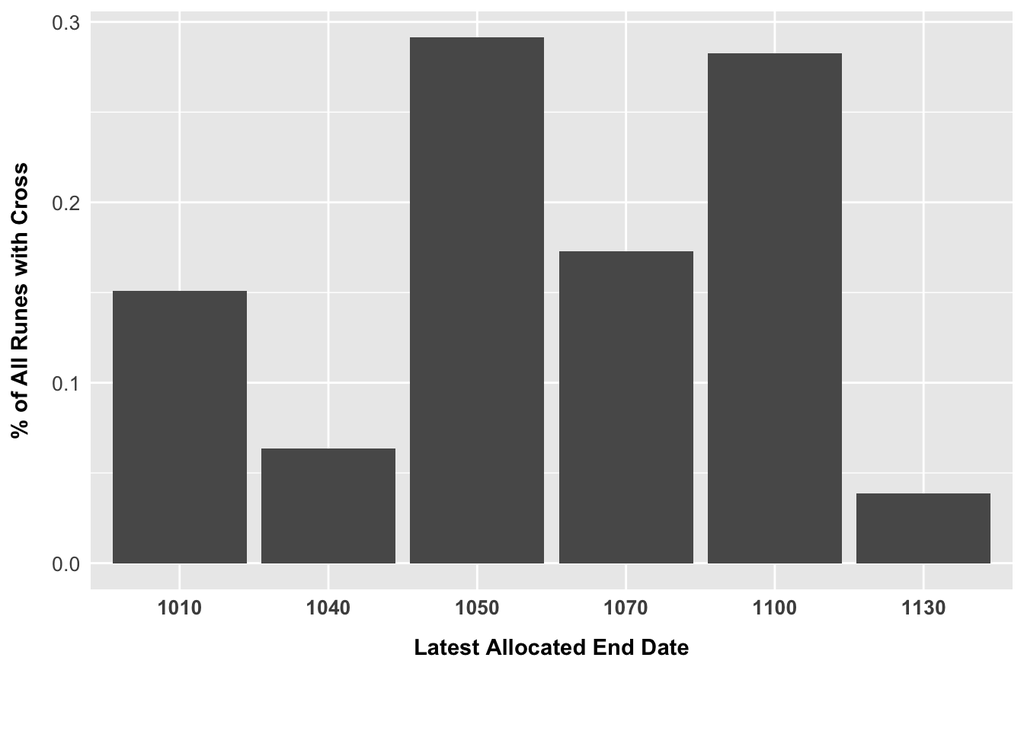

<sup>**Figure 6. Density distribution of all runes found with a typological cross feature by latest allocate end date.**</sup>

```r
g <- countsData %>%
  select(latestAD, 'Cross Y/N')%>%
  rename(f = 'Cross Y/N')%>%
  ggplot(aes()) +
  geom_col(aes(x=latestAD, y=f)) +
  ylab('Cross Y/N') +
  xlab("Time Period") +
  theme(axis.title.y = element_text(margin = margin(t = 0, r = 10, b = 0, l = 0), face = "bold"), axis.text.y = element_text(size = 10)) +
  theme(axis.title.x = element_text(margin = margin(t = 10, r = 0, b = 30, l = 0), face = "bold"), axis.ticks = element_blank(), axis.text.x = element_text(face = "bold", size = 10)) +
      xlab("Latest Allocated End Date") +
      ylab("% of All Runes with Cross") +
      theme(legend.position = "none")

g
```

Since crosses have been characterized as explicit markers of the Christian faith, runestones can be indicative of the introduction and spread of Christianity across Sweden (Zilmer, 2011). By analysing the differences in the number of crosses across the time periods, the influence of political and historical changes on the spread of Christianity can be deduced.

For example, the violent conflict between Blot-Sweyn, (supported Paganism) and Inge the Elder (supported Christianity) during 1070-1100 was a major factor in the rise and fall of Christianity across Sweden (“Inge the Elder”, 2019). The relative dip in the number of crosses on runestones during that period (Figure 6) could be explained by the ousting of Inge and the introduction of Blot-Sweyn as the new Swedish King. However, after several years Inge returned to Sweden, slaying the king. This monumental event was said to ‘complete’ the Christianisation of Sweden during the Viking Era as suggested through the spike in the number of Crosses in the 1100 AD time period.

Hence, it could be deduced that political changes drastically influenced the existence of Christianity across Sweden.

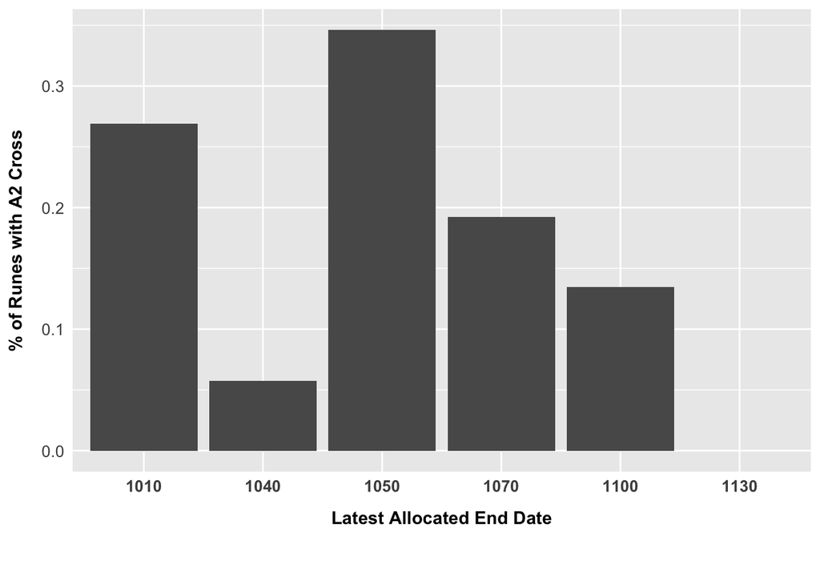

<sup>**Figure 7. Density distribution of all runes found with an A2, C2, E2 or E8 typological cross feature by latest allocate end date.**</sup>

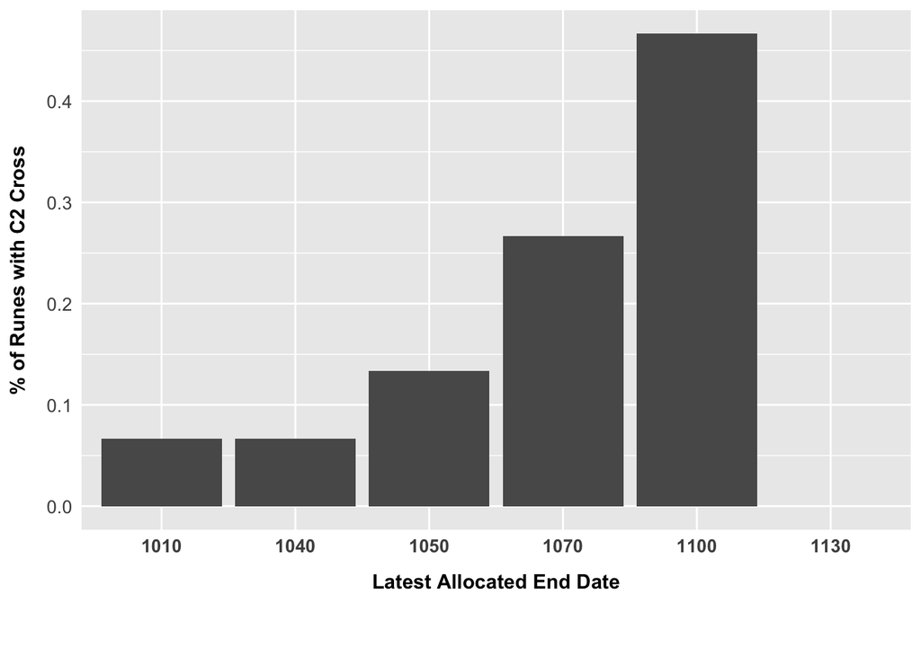

<sup>**Figure 7. Density distribution of all runes found with an A2, C2, E2 or E8 typological cross feature by latest allocate end date.**</sup>

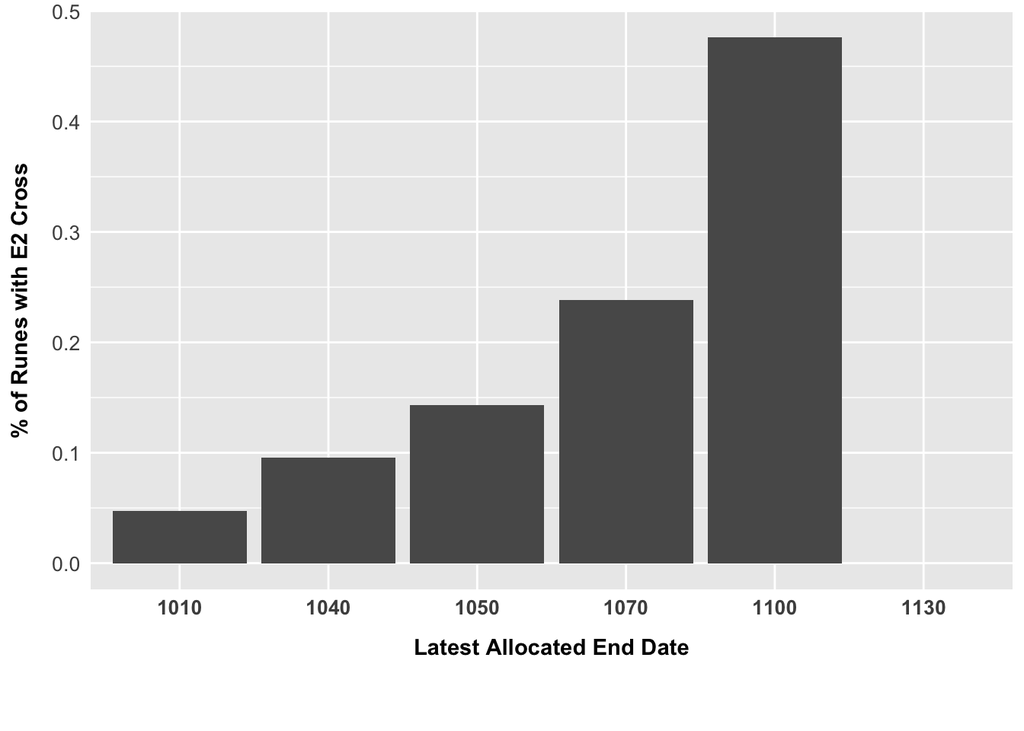

<sup>**Figure 7. Density distribution of all runes found with an A2, C2, E2 or E8 typological cross feature by latest allocate end date.**</sup>

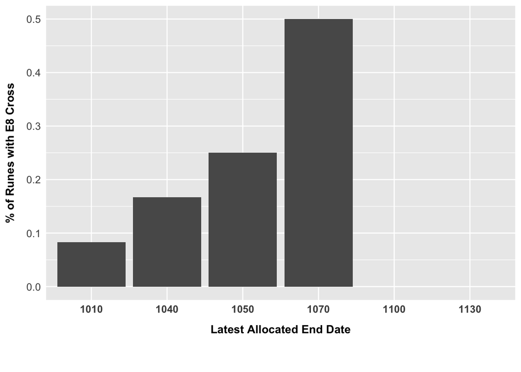

<sup>**Figure 7. Density distribution of all runes found with an A2, C2, E2 or E8 typological cross feature by latest allocate end date.**</sup>

```r
features = c("A2","C2","E2","E8")

for (feature in features){
  g <- countsData %>%
  select(latestAD, feature)%>%
  rename(f = feature)%>%
  ggplot() +
  geom_col(aes(x=latestAD, y=f)) +
  ylab(feature) +
  theme(axis.title.y = element_text(margin = margin(t = 0, r = 10, b = 0, l = 0), face = "bold"), axis.text.y = element_text(size = 10)) +
  theme(axis.title.x = element_text(margin = margin(t = 10, r = 0, b = 30, l = 0), face = "bold"), axis.ticks = element_blank(), axis.text.x = element_text(face = "bold", size = 10)) +
  xlab("Latest Allocated End Date") +
  ylab(paste("% of Runes with", feature, "Cross", sep=" ")) +
      theme(legend.position = "none")
  print(g)

}
```

# 3 Summary

In summary, this report has shown that Viking runestones are not evenly distributed both by time or by place within Sweden. It has also found that certain typological cross features show distinct trends over time, and that overall they may be explained by socio-political and religious events.

These findings suggest future studies may focus on dating techniques for runestones found in less represented provinces, or considering trends over time with respect to singular typological cross features.

# 4 References

- Kristel Zilmer. (2011). Current Swedish Archeology [Ebook] (pp. Volume 19, Page 87-88). Retrieved from http://www.arkeologiskasamfundet.se/csa/Dokument/Volumes/csa_vol_19_2011/csa_vol_19_2011_s87-112_zilmer.pdf
- Inge the Elder. (2019). Retrieved 27 September 2019, from https://en.wikipedia.org/wiki/Inge_the_Elder
- Lewis, D. (2005). Naïve (Bayes) at forty: The independence assumption in information retrieval. Machine Learning: ECML-98, 1398, 4-15.
- Thoeming, A. (2016). Dealing with data: Naïve Bayesian Classification and a Case Study from Viking Age Sweden. International Journal of Student Research in Archaeology, 1(1), 193-204.